# 3-2 Assignment: Identifying CIFAR-10 Images — Enhanced (CS 499 Milestone Three)

This notebook enhances the original CS 370 CIFAR-10 CNN assignment for the CS 499 capstone, Category Two: Algorithms and Data Structure.

**Fixes applied:**

- Corrected a `Conv2D(64, 3, 3)` positional-argument bug in the deeper network that was silently applying an unintended stride of 3 instead of a `(3,3)` kernel with default stride.
- Corrected a stale-evaluation bug where the augmented model's test score was never captured, so the printed results were actually the earlier baseline model's leftover values.

**Enhancements added:**

- Batch normalization after each convolutional layer.
- `ReduceLROnPlateau` learning-rate scheduling during training.
- A before/after convergence comparison isolating the effect of these two enhancements on the same architecture and data.

```python
!pip install -q -U tensorflow_datasets
```

```python
import tensorflow as tf
print(tf.config.list_physical_devices('GPU'))
```

```
[PhysicalDevice(name='/physical_device:GPU:0', device_type='GPU')]
```

```python
from google.colab import drive
drive.mount('/content/drive')

import os
os.makedirs('/content/drive/MyDrive/keras_datasets', exist_ok=True)

# Point Keras's dataset cache at your Drive folder instead of the default local one
os.environ['KERAS_HOME'] = '/content/drive/MyDrive/keras_datasets'
```

```python
from keras.datasets import cifar10
from keras.utils import to_categorical
from keras.models import Sequential
from keras.layers import Dense, Dropout, Activation, Flatten, BatchNormalization
from keras.layers import Conv2D, MaxPooling2D
from keras.optimizers import RMSprop
from keras.callbacks import ReduceLROnPlateau
import matplotlib.pyplot as plt
import tensorflow as tf
import numpy as np
import os
```

```python
# CIFAR-10 is a set of 60K images, 32 x 32 pixels, 3 channels
IMG_CHANNELS = 3
IMG_ROWS = 32
IMG_COLS = 32

# Constants
BATCH_SIZE = 128
NB_EPOCH = 20
NB_CLASSES = 10
VERBOSE = 1
VALIDATION_SPLIT = 0.2
OPTIM = RMSprop()
```

```python
# Load the dataset
import time
from keras.datasets import cifar10

for attempt in range(3):
    try:
        (X_train, y_train), (X_test, y_test) = cifar10.load_data()
        break
    except Exception as e:
        print(f"Attempt {attempt + 1} failed: {e}, retrying...")
        time.sleep(5)

print('X_train shape:', X_train.shape)
print(X_train.shape[0], 'train samples')
print(X_test.shape[0], 'test samples')
```

```
Downloading data from https://www.cs.toronto.edu/~kriz/cifar-10-python.tar.gz
170498071/170498071 ━━━━━━━━━━━━━━━━━━━━ 3032s 18us/step
X_train shape: (50000, 32, 32, 3)
50000 train samples
10000 test samples
```

```python
Y_train = to_categorical(y_train, NB_CLASSES)
Y_test = to_categorical(y_test, NB_CLASSES)

# float and normalization
X_train = X_train.astype('float32')
X_test = X_test.astype('float32')
X_train /= 255
X_test /= 255
```

## Original Baseline Model

This is the simple single-block CNN from the original assignment, kept as-is to confirm the pipeline still runs end to end before moving into the enhanced deeper network below.

```python
baseline_model = Sequential()
baseline_model.add(Conv2D(32, (3, 3), padding="same",
                input_shape=(IMG_ROWS, IMG_COLS, IMG_CHANNELS)))
baseline_model.add(Activation('relu'))
baseline_model.add(MaxPooling2D(pool_size=(2, 2)))
baseline_model.add(Dropout(0.25))
baseline_model.add(Flatten())
baseline_model.add(Dense(512))
baseline_model.add(Activation('relu'))
baseline_model.add(Dropout(0.5))
baseline_model.add(Dense(NB_CLASSES))
baseline_model.add(Activation('softmax'))
baseline_model.summary()
```

```
Model: "sequential"
```

```
┏━━━━━━━━━━━━━━━━━━━━━━━━━━━━━━━━━┳━━━━━━━━━━━━━━━━━━━━━━━━┳━━━━━━━━━━━━━━━┓
┃ Layer (type)                    ┃ Output Shape           ┃       Param # ┃
┡━━━━━━━━━━━━━━━━━━━━━━━━━━━━━━━━━╇━━━━━━━━━━━━━━━━━━━━━━━━╇━━━━━━━━━━━━━━━┩
│ conv2d (Conv2D)                 │ (None, 32, 32, 32)     │           896 │
├─────────────────────────────────┼────────────────────────┼───────────────┤
│ activation (Activation)         │ (None, 32, 32, 32)     │             0 │
├─────────────────────────────────┼────────────────────────┼───────────────┤
│ max_pooling2d (MaxPooling2D)    │ (None, 16, 16, 32)     │             0 │
├─────────────────────────────────┼────────────────────────┼───────────────┤
│ dropout (Dropout)               │ (None, 16, 16, 32)     │             0 │
├─────────────────────────────────┼────────────────────────┼───────────────┤
│ flatten (Flatten)               │ (None, 8192)           │             0 │
├─────────────────────────────────┼────────────────────────┼───────────────┤
│ dense (Dense)                   │ (None, 512)            │     4,194,816 │
├─────────────────────────────────┼────────────────────────┼───────────────┤
│ activation_1 (Activation)       │ (None, 512)            │             0 │
├─────────────────────────────────┼────────────────────────┼───────────────┤
│ dropout_1 (Dropout)             │ (None, 512)            │             0 │
├─────────────────────────────────┼────────────────────────┼───────────────┤
│ dense_1 (Dense)                 │ (None, 10)             │         5,130 │
├─────────────────────────────────┼────────────────────────┼───────────────┤
│ activation_2 (Activation)       │ (None, 10)             │             0 │
└─────────────────────────────────┴────────────────────────┴───────────────┘
```

```
 Total params: 4,200,842 (16.02 MB)
```

```
 Trainable params: 4,200,842 (16.02 MB)
```

```
 Non-trainable params: 0 (0.00 B)
```

```python
baseline_model.compile(loss="categorical_crossentropy", optimizer=OPTIM, metrics=["accuracy"])
baseline_model.fit(X_train, Y_train, batch_size=BATCH_SIZE, epochs=NB_EPOCH,
                    validation_split=VALIDATION_SPLIT, verbose=VERBOSE)
baseline_score = baseline_model.evaluate(X_test, Y_test, batch_size=BATCH_SIZE, verbose=VERBOSE)
print('Baseline Test Score:', baseline_score[0])
print('Baseline Test Accuracy:', baseline_score[1])
```

```
313/313 ━━━━━━━━━━━━━━━━━━━━ 9s 17ms/step - accuracy: 0.3765 - loss: 1.7526 - val_accuracy: 0.5060 - val_loss: 1.4185
313/313 ━━━━━━━━━━━━━━━━━━━━ 2s 8ms/step - accuracy: 0.5013 - loss: 1.4048 - val_accuracy: 0.5465 - val_loss: 1.2849
313/313 ━━━━━━━━━━━━━━━━━━━━ 2s 7ms/step - accuracy: 0.5446 - loss: 1.2782 - val_accuracy: 0.5606 - val_loss: 1.2433
313/313 ━━━━━━━━━━━━━━━━━━━━ 2s 6ms/step - accuracy: 0.5775 - loss: 1.1938 - val_accuracy: 0.5891 - val_loss: 1.1605
313/313 ━━━━━━━━━━━━━━━━━━━━ 2s 6ms/step - accuracy: 0.6048 - loss: 1.1212 - val_accuracy: 0.6284 - val_loss: 1.0702
313/313 ━━━━━━━━━━━━━━━━━━━━ 2s 6ms/step - accuracy: 0.6320 - loss: 1.0590 - val_accuracy: 0.6046 - val_loss: 1.1324
313/313 ━━━━━━━━━━━━━━━━━━━━ 2s 6ms/step - accuracy: 0.6482 - loss: 1.0057 - val_accuracy: 0.6141 - val_loss: 1.1044
313/313 ━━━━━━━━━━━━━━━━━━━━ 2s 6ms/step - accuracy: 0.6642 - loss: 0.9521 - val_accuracy: 0.6401 - val_loss: 1.0335
313/313 ━━━━━━━━━━━━━━━━━━━━ 2s 7ms/step - accuracy: 0.6833 - loss: 0.9024 - val_accuracy: 0.6517 - val_loss: 1.0123
313/313 ━━━━━━━━━━━━━━━━━━━━ 2s 7ms/step - accuracy: 0.6969 - loss: 0.8607 - val_accuracy: 0.6530 - val_loss: 1.0073
313/313 ━━━━━━━━━━━━━━━━━━━━ 2s 6ms/step - accuracy: 0.7146 - loss: 0.8178 - val_accuracy: 0.6597 - val_loss: 0.9947
313/313 ━━━━━━━━━━━━━━━━━━━━ 2s 6ms/step - accuracy: 0.7296 - loss: 0.7744 - val_accuracy: 0.6667 - val_loss: 1.0019
313/313 ━━━━━━━━━━━━━━━━━━━━ 2s 6ms/step - accuracy: 0.7421 - loss: 0.7371 - val_accuracy: 0.6749 - val_loss: 0.9630
313/313 ━━━━━━━━━━━━━━━━━━━━ 3s 6ms/step - accuracy: 0.7546 - loss: 0.6999 - val_accuracy: 0.6635 - val_loss: 0.9793
313/313 ━━━━━━━━━━━━━━━━━━━━ 2s 6ms/step - accuracy: 0.7688 - loss: 0.6623 - val_accuracy: 0.6733 - val_loss: 0.9686
313/313 ━━━━━━━━━━━━━━━━━━━━ 2s 7ms/step - accuracy: 0.7815 - loss: 0.6232 - val_accuracy: 0.6768 - val_loss: 1.0198
313/313 ━━━━━━━━━━━━━━━━━━━━ 2s 6ms/step - accuracy: 0.7912 - loss: 0.5945 - val_accuracy: 0.6754 - val_loss: 0.9855
313/313 ━━━━━━━━━━━━━━━━━━━━ 2s 6ms/step - accuracy: 0.8043 - loss: 0.5623 - val_accuracy: 0.6829 - val_loss: 0.9713
313/313 ━━━━━━━━━━━━━━━━━━━━ 2s 6ms/step - accuracy: 0.8167 - loss: 0.5305 - val_accuracy: 0.6778 - val_loss: 1.0087
313/313 ━━━━━━━━━━━━━━━━━━━━ 2s 6ms/step - accuracy: 0.8238 - loss: 0.5065 - val_accuracy: 0.6826 - val_loss: 1.0131
79/79 ━━━━━━━━━━━━━━━━━━━━ 0s 3ms/step - accuracy: 0.6789 - loss: 1.0188
Baseline Test Score: 1.018812656402588
Baseline Test Accuracy: 0.6789000034332275
```

## Deeper Network Architecture

Built as a function so the same architecture can be instantiated with or without batch normalization, which lets the before/after comparison later isolate the effect of that single enhancement.

**Bug fix:** the second 64-filter convolution originally read `Conv2D(64, 3, 3)`, which Keras parses as `kernel_size=3, strides=3` rather than the intended `(3,3)` kernel with default stride — silently breaking the downsampling and dropping the `padding='same'` used by every sibling layer. It is corrected below to `Conv2D(64, (3, 3), padding='same')`.

```python
def build_deeper_model(batch_norm=False):
    model = Sequential()

    model.add(Conv2D(32, (3, 3), padding='same', input_shape=(IMG_ROWS, IMG_COLS, IMG_CHANNELS)))
    if batch_norm:
        model.add(BatchNormalization())
    model.add(Activation('relu'))

    model.add(Conv2D(32, (3, 3), padding='same'))
    if batch_norm:
        model.add(BatchNormalization())
    model.add(Activation('relu'))
    model.add(MaxPooling2D(pool_size=(2, 2)))
    model.add(Dropout(0.25))

    model.add(Conv2D(64, (3, 3), padding='same'))
    if batch_norm:
        model.add(BatchNormalization())
    model.add(Activation('relu'))

    model.add(Conv2D(64, (3, 3), padding='same'))  # FIXED: was Conv2D(64, 3, 3)
    if batch_norm:
        model.add(BatchNormalization())
    model.add(Activation('relu'))
    model.add(MaxPooling2D(pool_size=(2, 2)))
    model.add(Dropout(0.25))

    model.add(Flatten())
    model.add(Dense(512))
    model.add(Activation('relu'))
    model.add(Dropout(0.5))
    model.add(Dense(NB_CLASSES))
    model.add(Activation('softmax'))
    return model

build_deeper_model(batch_norm=True).summary()
```

```
Model: "sequential_1"
```

```
┏━━━━━━━━━━━━━━━━━━━━━━━━━━━━━━━━━┳━━━━━━━━━━━━━━━━━━━━━━━━┳━━━━━━━━━━━━━━━┓
┃ Layer (type)                    ┃ Output Shape           ┃       Param # ┃
┡━━━━━━━━━━━━━━━━━━━━━━━━━━━━━━━━━╇━━━━━━━━━━━━━━━━━━━━━━━━╇━━━━━━━━━━━━━━━┩
│ conv2d_1 (Conv2D)               │ (None, 32, 32, 32)     │           896 │
├─────────────────────────────────┼────────────────────────┼───────────────┤
│ batch_normalization             │ (None, 32, 32, 32)     │           128 │
│ (BatchNormalization)            │                        │               │
├─────────────────────────────────┼────────────────────────┼───────────────┤
│ activation_3 (Activation)       │ (None, 32, 32, 32)     │             0 │
├─────────────────────────────────┼────────────────────────┼───────────────┤
│ conv2d_2 (Conv2D)               │ (None, 32, 32, 32)     │         9,248 │
├─────────────────────────────────┼────────────────────────┼───────────────┤
│ batch_normalization_1           │ (None, 32, 32, 32)     │           128 │
│ (BatchNormalization)            │                        │               │
├─────────────────────────────────┼────────────────────────┼───────────────┤
│ activation_4 (Activation)       │ (None, 32, 32, 32)     │             0 │
├─────────────────────────────────┼────────────────────────┼───────────────┤
│ max_pooling2d_1 (MaxPooling2D)  │ (None, 16, 16, 32)     │             0 │
├─────────────────────────────────┼────────────────────────┼───────────────┤
│ dropout_2 (Dropout)             │ (None, 16, 16, 32)     │             0 │
├─────────────────────────────────┼────────────────────────┼───────────────┤
│ conv2d_3 (Conv2D)               │ (None, 16, 16, 64)     │        18,496 │
├─────────────────────────────────┼────────────────────────┼───────────────┤
│ batch_normalization_2           │ (None, 16, 16, 64)     │           256 │
│ (BatchNormalization)            │                        │               │
├─────────────────────────────────┼────────────────────────┼───────────────┤
│ activation_5 (Activation)       │ (None, 16, 16, 64)     │             0 │
├─────────────────────────────────┼────────────────────────┼───────────────┤
│ conv2d_4 (Conv2D)               │ (None, 16, 16, 64)     │        36,928 │
├─────────────────────────────────┼────────────────────────┼───────────────┤
│ batch_normalization_3           │ (None, 16, 16, 64)     │           256 │
│ (BatchNormalization)            │                        │               │
├─────────────────────────────────┼────────────────────────┼───────────────┤
│ activation_6 (Activation)       │ (None, 16, 16, 64)     │             0 │
├─────────────────────────────────┼────────────────────────┼───────────────┤
│ max_pooling2d_2 (MaxPooling2D)  │ (None, 8, 8, 64)       │             0 │
├─────────────────────────────────┼────────────────────────┼───────────────┤
│ dropout_3 (Dropout)             │ (None, 8, 8, 64)       │             0 │
├─────────────────────────────────┼────────────────────────┼───────────────┤
│ flatten_1 (Flatten)             │ (None, 4096)           │             0 │
├─────────────────────────────────┼────────────────────────┼───────────────┤
│ dense_2 (Dense)                 │ (None, 512)            │     2,097,664 │
├─────────────────────────────────┼────────────────────────┼───────────────┤
│ activation_7 (Activation)       │ (None, 512)            │             0 │
├─────────────────────────────────┼────────────────────────┼───────────────┤
│ dropout_4 (Dropout)             │ (None, 512)            │             0 │
├─────────────────────────────────┼────────────────────────┼───────────────┤
│ dense_3 (Dense)                 │ (None, 10)             │         5,130 │
├─────────────────────────────────┼────────────────────────┼───────────────┤
│ activation_8 (Activation)       │ (None, 10)             │             0 │
└─────────────────────────────────┴────────────────────────┴───────────────┘
```

```
 Total params: 2,169,130 (8.27 MB)
```

```
 Trainable params: 2,168,746 (8.27 MB)
```

```
 Non-trainable params: 384 (1.50 KB)
```

## Data Augmentation

Same augmentation strategy as the original assignment. The unused sample-preview loop that wrote augmented images to disk without feeding them into training has been removed, since it added runtime cost without affecting the model.

```python
from tensorflow.keras.preprocessing.image import ImageDataGenerator

NUM_TO_AUGMENT = 5

print("Setting up training image augmentation...")
datagen = ImageDataGenerator(
    rotation_range=40,
    width_shift_range=0.2,
    height_shift_range=0.2,
    zoom_range=0.2,
    horizontal_flip=True,
    fill_mode='nearest'
)
datagen.fit(X_train)
```

```
Setting up training image augmentation...
```

## Before: Deeper Network, No Batch Normalization, No LR Scheduling

This trains the corrected deeper network (Conv2D bug already fixed) on augmented data using the original training setup, with no batch normalization and a fixed learning rate. This run is the "before" side of the convergence comparison.

```python
def make_augmented_dataset(datagen, X, Y, batch_size):
    ds = tf.data.Dataset.from_generator(
        lambda: datagen.flow(X, Y, batch_size=batch_size, shuffle=True),
        output_signature=(
            tf.TensorSpec(shape=(None, IMG_ROWS, IMG_COLS, IMG_CHANNELS), dtype=tf.float32),
            tf.TensorSpec(shape=(None, NB_CLASSES), dtype=tf.float32),
        )
    )
    return ds.repeat()

model_before = build_deeper_model(batch_norm=False)
model_before.compile(loss="categorical_crossentropy", optimizer=RMSprop(), metrics=["accuracy"])

history_before = model_before.fit(
    make_augmented_dataset(datagen, X_train, Y_train, BATCH_SIZE),
    steps_per_epoch=X_train.shape[0] // BATCH_SIZE,
    epochs=NB_EPOCH,
    validation_data=(X_test, Y_test),
    verbose=VERBOSE
)

score_before = model_before.evaluate(X_test, Y_test, batch_size=BATCH_SIZE, verbose=VERBOSE)
print("Before Enhancement — Test Score:", score_before[0])
print("Before Enhancement — Test Accuracy:", score_before[1])
```

```
390/390 ━━━━━━━━━━━━━━━━━━━━ 40s 90ms/step - accuracy: 0.2823 - loss: 1.9548 - val_accuracy: 0.4497 - val_loss: 1.5107
390/390 ━━━━━━━━━━━━━━━━━━━━ 35s 83ms/step - accuracy: 0.3939 - loss: 1.6731 - val_accuracy: 0.4960 - val_loss: 1.3724
390/390 ━━━━━━━━━━━━━━━━━━━━ 34s 88ms/step - accuracy: 0.4409 - loss: 1.5463 - val_accuracy: 0.4877 - val_loss: 1.4524
390/390 ━━━━━━━━━━━━━━━━━━━━ 32s 83ms/step - accuracy: 0.4730 - loss: 1.4657 - val_accuracy: 0.5616 - val_loss: 1.2275
390/390 ━━━━━━━━━━━━━━━━━━━━ 31s 81ms/step - accuracy: 0.4978 - loss: 1.3926 - val_accuracy: 0.6146 - val_loss: 1.0783
390/390 ━━━━━━━━━━━━━━━━━━━━ 32s 81ms/step - accuracy: 0.5204 - loss: 1.3434 - val_accuracy: 0.6225 - val_loss: 1.0658
390/390 ━━━━━━━━━━━━━━━━━━━━ 33s 85ms/step - accuracy: 0.5370 - loss: 1.3025 - val_accuracy: 0.6399 - val_loss: 1.0349
390/390 ━━━━━━━━━━━━━━━━━━━━ 32s 83ms/step - accuracy: 0.5521 - loss: 1.2653 - val_accuracy: 0.5799 - val_loss: 1.1719
390/390 ━━━━━━━━━━━━━━━━━━━━ 31s 80ms/step - accuracy: 0.5613 - loss: 1.2365 - val_accuracy: 0.6574 - val_loss: 0.9725
390/390 ━━━━━━━━━━━━━━━━━━━━ 31s 80ms/step - accuracy: 0.5701 - loss: 1.2153 - val_accuracy: 0.6323 - val_loss: 1.0599
390/390 ━━━━━━━━━━━━━━━━━━━━ 32s 82ms/step - accuracy: 0.5779 - loss: 1.1876 - val_accuracy: 0.6335 - val_loss: 1.0636
390/390 ━━━━━━━━━━━━━━━━━━━━ 33s 84ms/step - accuracy: 0.5916 - loss: 1.1616 - val_accuracy: 0.6804 - val_loss: 0.9091
390/390 ━━━━━━━━━━━━━━━━━━━━ 32s 82ms/step - accuracy: 0.6004 - loss: 1.1467 - val_accuracy: 0.6480 - val_loss: 1.0022
390/390 ━━━━━━━━━━━━━━━━━━━━ 31s 80ms/step - accuracy: 0.6034 - loss: 1.1220 - val_accuracy: 0.6702 - val_loss: 0.9325
390/390 ━━━━━━━━━━━━━━━━━━━━ 31s 80ms/step - accuracy: 0.6081 - loss: 1.1139 - val_accuracy: 0.6780 - val_loss: 0.9499
390/390 ━━━━━━━━━━━━━━━━━━━━ 32s 81ms/step - accuracy: 0.6150 - loss: 1.0998 - val_accuracy: 0.6650 - val_loss: 0.9746
390/390 ━━━━━━━━━━━━━━━━━━━━ 33s 84ms/step - accuracy: 0.6157 - loss: 1.0954 - val_accuracy: 0.6904 - val_loss: 0.8999
390/390 ━━━━━━━━━━━━━━━━━━━━ 31s 81ms/step - accuracy: 0.6226 - loss: 1.0784 - val_accuracy: 0.6934 - val_loss: 0.8788
390/390 ━━━━━━━━━━━━━━━━━━━━ 32s 81ms/step - accuracy: 0.6230 - loss: 1.0787 - val_accuracy: 0.6837 - val_loss: 0.9247
390/390 ━━━━━━━━━━━━━━━━━━━━ 31s 80ms/step - accuracy: 0.6305 - loss: 1.0608 - val_accuracy: 0.6922 - val_loss: 0.9081
79/79 ━━━━━━━━━━━━━━━━━━━━ 1s 6ms/step - accuracy: 0.6922 - loss: 0.9081
Before Enhancement — Test Score: 0.908058762550354
Before Enhancement — Test Accuracy: 0.6922000050544739
```

## After: Deeper Network, With Batch Normalization and ReduceLROnPlateau

Same architecture and same augmented data, this time with batch normalization enabled and a `ReduceLROnPlateau` callback that halves the learning rate whenever validation loss stalls for 3 consecutive epochs. This is the "after" side of the comparison.

**Bug fix:** the original code commented out `score = model.evaluate(...)` after this training block, so the print statements below it were reporting the earlier baseline model's leftover `score` variable instead of this model's actual results. `score_after` is captured explicitly below to fix that.

```python
model_after = build_deeper_model(batch_norm=True)
model_after.compile(loss="categorical_crossentropy", optimizer=RMSprop(), metrics=["accuracy"])

reduce_lr = ReduceLROnPlateau(monitor='val_loss', factor=0.5, patience=3, min_lr=1e-6, verbose=1)

history_after = model_after.fit(
    make_augmented_dataset(datagen, X_train, Y_train, BATCH_SIZE),
    steps_per_epoch=X_train.shape[0] // BATCH_SIZE,
    epochs=NB_EPOCH,
    validation_data=(X_test, Y_test),
    callbacks=[reduce_lr],
    verbose=VERBOSE
)

score_after = model_after.evaluate(X_test, Y_test, batch_size=BATCH_SIZE, verbose=VERBOSE)
print("After Enhancement — Test Score:", score_after[0])
print("After Enhancement — Test Accuracy:", score_after[1])
```

```
390/390 ━━━━━━━━━━━━━━━━━━━━ 41s 89ms/step - accuracy: 0.2934 - loss: 2.1684 - val_accuracy: 0.3124 - val_loss: 1.8940 - learning_rate: 0.0010
390/390 ━━━━━━━━━━━━━━━━━━━━ 37s 80ms/step - accuracy: 0.3864 - loss: 1.6841 - val_accuracy: 0.4642 - val_loss: 1.5443 - learning_rate: 0.0010
390/390 ━━━━━━━━━━━━━━━━━━━━ 33s 84ms/step - accuracy: 0.4253 - loss: 1.5815 - val_accuracy: 0.5034 - val_loss: 1.4353 - learning_rate: 0.0010
390/390 ━━━━━━━━━━━━━━━━━━━━ 32s 82ms/step - accuracy: 0.4618 - loss: 1.5033 - val_accuracy: 0.4135 - val_loss: 2.2317 - learning_rate: 0.0010
390/390 ━━━━━━━━━━━━━━━━━━━━ 32s 83ms/step - accuracy: 0.4827 - loss: 1.4361 - val_accuracy: 0.5399 - val_loss: 1.2708 - learning_rate: 0.0010
390/390 ━━━━━━━━━━━━━━━━━━━━ 32s 82ms/step - accuracy: 0.5043 - loss: 1.3799 - val_accuracy: 0.4832 - val_loss: 1.5746 - learning_rate: 0.0010
390/390 ━━━━━━━━━━━━━━━━━━━━ 32s 81ms/step - accuracy: 0.5248 - loss: 1.3349 - val_accuracy: 0.5291 - val_loss: 1.3648 - learning_rate: 0.0010
390/390 ━━━━━━━━━━━━━━━━━━━━ 0s 76ms/step - accuracy: 0.5436 - loss: 1.2902
Epoch 8: ReduceLROnPlateau reducing learning rate to 0.0005000000237487257.
390/390 ━━━━━━━━━━━━━━━━━━━━ 31s 81ms/step - accuracy: 0.5445 - loss: 1.2871 - val_accuracy: 0.5535 - val_loss: 1.3356 - learning_rate: 0.0010
390/390 ━━━━━━━━━━━━━━━━━━━━ 31s 80ms/step - accuracy: 0.5717 - loss: 1.2131 - val_accuracy: 0.6093 - val_loss: 1.1385 - learning_rate: 5.0000e-04
390/390 ━━━━━━━━━━━━━━━━━━━━ 32s 81ms/step - accuracy: 0.5784 - loss: 1.1876 - val_accuracy: 0.5306 - val_loss: 1.4019 - learning_rate: 5.0000e-04
390/390 ━━━━━━━━━━━━━━━━━━━━ 31s 80ms/step - accuracy: 0.5915 - loss: 1.1624 - val_accuracy: 0.6250 - val_loss: 1.0841 - learning_rate: 5.0000e-04
390/390 ━━━━━━━━━━━━━━━━━━━━ 31s 79ms/step - accuracy: 0.5955 - loss: 1.1453 - val_accuracy: 0.6324 - val_loss: 1.0485 - learning_rate: 5.0000e-04
390/390 ━━━━━━━━━━━━━━━━━━━━ 31s 79ms/step - accuracy: 0.6026 - loss: 1.1271 - val_accuracy: 0.6194 - val_loss: 1.1025 - learning_rate: 5.0000e-04
390/390 ━━━━━━━━━━━━━━━━━━━━ 32s 81ms/step - accuracy: 0.6096 - loss: 1.1108 - val_accuracy: 0.6302 - val_loss: 1.1176 - learning_rate: 5.0000e-04
390/390 ━━━━━━━━━━━━━━━━━━━━ 31s 79ms/step - accuracy: 0.6095 - loss: 1.1070 - val_accuracy: 0.6448 - val_loss: 1.0418 - learning_rate: 5.0000e-04
390/390 ━━━━━━━━━━━━━━━━━━━━ 32s 83ms/step - accuracy: 0.6170 - loss: 1.0940 - val_accuracy: 0.6585 - val_loss: 0.9819 - learning_rate: 5.0000e-04
390/390 ━━━━━━━━━━━━━━━━━━━━ 32s 82ms/step - accuracy: 0.6222 - loss: 1.0788 - val_accuracy: 0.6405 - val_loss: 1.0485 - learning_rate: 5.0000e-04
390/390 ━━━━━━━━━━━━━━━━━━━━ 33s 84ms/step - accuracy: 0.6271 - loss: 1.0675 - val_accuracy: 0.5905 - val_loss: 1.3620 - learning_rate: 5.0000e-04
390/390 ━━━━━━━━━━━━━━━━━━━━ 0s 75ms/step - accuracy: 0.6265 - loss: 1.0584
Epoch 19: ReduceLROnPlateau reducing learning rate to 0.0002500000118743628.
390/390 ━━━━━━━━━━━━━━━━━━━━ 31s 80ms/step - accuracy: 0.6273 - loss: 1.0617 - val_accuracy: 0.6541 - val_loss: 0.9943 - learning_rate: 5.0000e-04
390/390 ━━━━━━━━━━━━━━━━━━━━ 33s 84ms/step - accuracy: 0.6435 - loss: 1.0285 - val_accuracy: 0.6600 - val_loss: 1.0101 - learning_rate: 2.5000e-04
79/79 ━━━━━━━━━━━━━━━━━━━━ 1s 5ms/step - accuracy: 0.6600 - loss: 1.0101
After Enhancement — Test Score: 1.010133981704712
After Enhancement — Test Accuracy: 0.6600000262260437
```

## Convergence Comparison

Validation accuracy and validation loss, before vs. after, plotted per epoch.

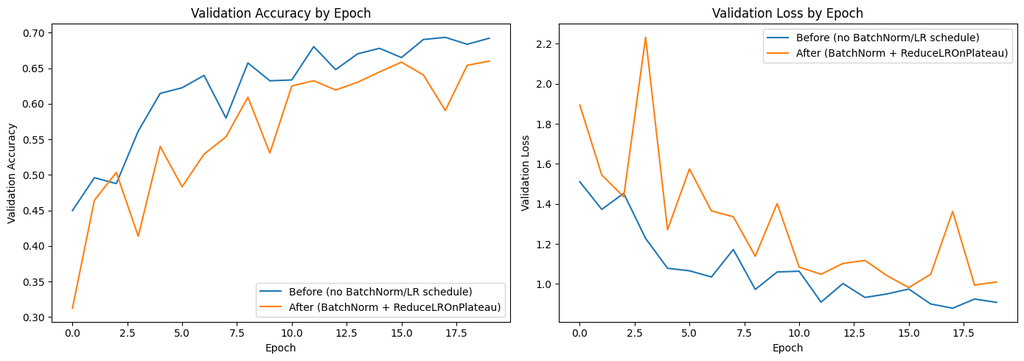

```
Metric                    Before       After
Test Accuracy             0.6922      0.6600
Test Loss                 0.9081      1.0101
```

```python
fig, axes = plt.subplots(1, 2, figsize=(14, 5))

axes[0].plot(history_before.history['val_accuracy'], label='Before (no BatchNorm/LR schedule)')
axes[0].plot(history_after.history['val_accuracy'], label='After (BatchNorm + ReduceLROnPlateau)')
axes[0].set_title('Validation Accuracy by Epoch')
axes[0].set_xlabel('Epoch')
axes[0].set_ylabel('Validation Accuracy')
axes[0].legend()

axes[1].plot(history_before.history['val_loss'], label='Before (no BatchNorm/LR schedule)')
axes[1].plot(history_after.history['val_loss'], label='After (BatchNorm + ReduceLROnPlateau)')
axes[1].set_title('Validation Loss by Epoch')
axes[1].set_xlabel('Epoch')
axes[1].set_ylabel('Validation Loss')
axes[1].legend()

plt.tight_layout()
plt.show()

print(f"{'Metric':<20}{'Before':>12}{'After':>12}")
print(f"{'Test Accuracy':<20}{score_before[1]:>12.4f}{score_after[1]:>12.4f}")
print(f"{'Test Loss':<20}{score_before[0]:>12.4f}{score_after[0]:>12.4f}")
```

## Save the Enhanced Model

```python
os.makedirs('output', exist_ok=True)
model_json = model_after.to_json()
open('./output/cifar10_architecture_enhanced.json', 'w').write(model_json)
model_after.save_weights('./output/cifar10_enhanced.weights.h5', overwrite=True)
```